# Classification problem of Bank’s Telemarketing Campaign_Project 3

```python
df_bank[['age_group', 'subscribed']].value_counts()
```

```
age_group           subscribed
Middle_Aged Adults  no            20277
Young_Adults        no            12829
Older_Adults        no             3082
Young_Adults        yes            1922
Middle_Aged Adults  yes            1920
Older_Adults        yes             484
Seniors             no              349
                    yes             311
dtype: int64
```

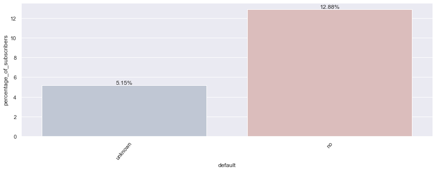

```python
# Running function for the 'default' column

statPlot('default')
```

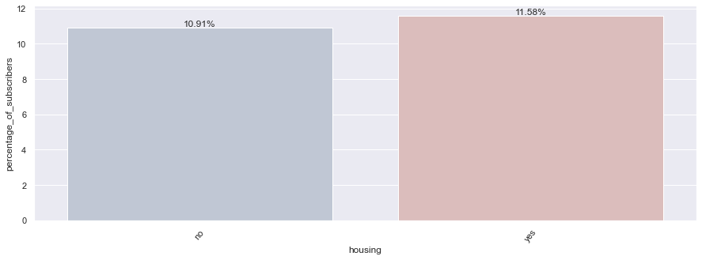

```python
statPlot('housing')
```

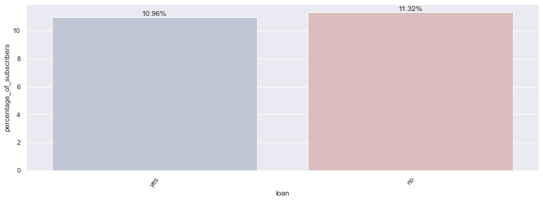

```python
# Running function for the 'loan' column
statPlot('loan')
```

```python
df_bank[['contact','subscribed']].value_counts()
```

```
contact    subscribed
cellular   no            22283
telephone  no            14254
cellular   yes            3852
telephone  yes             787
dtype: int64
```

```python
df_bank['contact'].value_counts()
```

```
cellular     26135
telephone    15041
Name: contact, dtype: int64
```

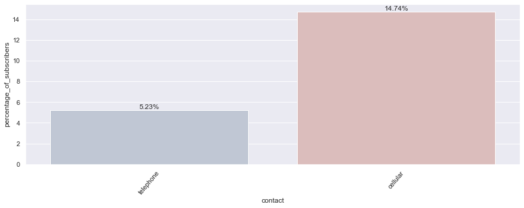

```python
# Running function for the 'contact' column
statPlot('contact')
```

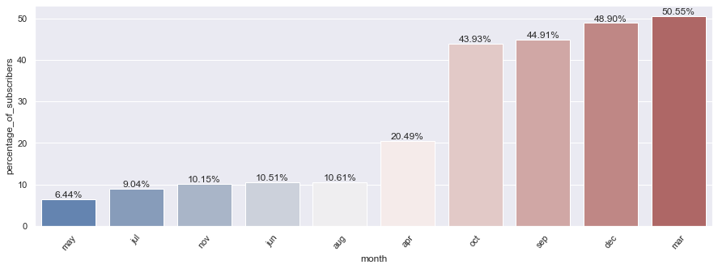

```python
# Running function for the 'month' column

statPlot('month')
```

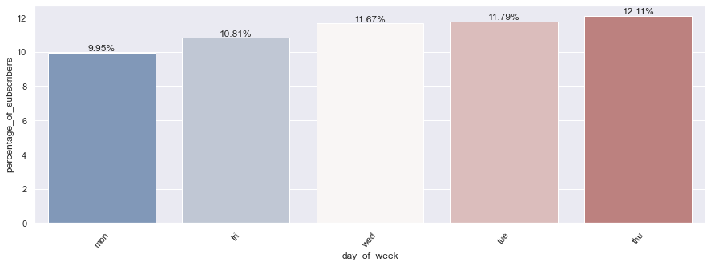

```python
# Running function for the 'day_of_week' column

statPlot('day_of_week')
```

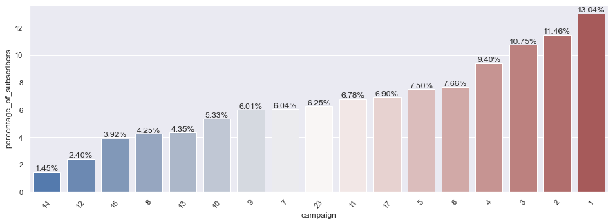

```python
# Running function for the 'campaign' column

statPlot('campaign')
```

#### Adding bins for the ‘campaign’ column - for the presentation

```python
df_bank["campaign"].describe()
```

```
count    41176.000000
mean         2.567879
std          2.770318
min          1.000000
25%          1.000000
50%          2.000000
75%          3.000000
max         56.000000
Name: campaign, dtype: float64
```

```python
#Here are the  bins  based on the values observed above.
# 5 values will result in 4 bins

bins = [1, 6, 10, 20, 50]

#We'll pd.cut method to separate data into bins.
df_bank['bins_camp'] = pd.cut(df_bank['campaign'], bins)

# I will use .cat.as_unordered() method transforming the data to
# ordered categories.
# bins_age_built = bins_yr_built.cat.as_unordered()
# bins_yr_built.head()
```

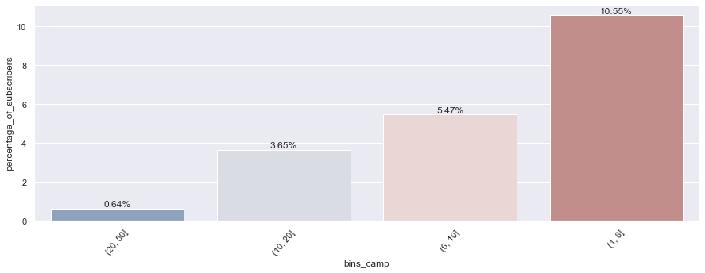

```python
statPlot('bins_camp')
```

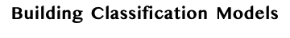

#### I will drop off the ‘duration’ column since the time of the call will not be known before contacting the prospect, and therefore including it in the model would create an unrealistic prediction. The variables included need to be known prior to the campaign call to assist businesses in targeting certain segments of the population.

```python
df_bank.drop(['duration','bins_age','bins_camp'],axis=1,inplace=True)
```

```python
# Changing ‘Yes’ to ‘1’ and ‘No’ to ‘0’ in order to have numerical values for
# our target variable.
dic_sub = {'yes':1,'no':0}

df_bank['subscribed'] = df_bank['subscribed'].map(dic_sub)

df_bank['subscribed']
```

```
0        0
1        0
2        0
3        0
4        0
        ..
41183    1
41184    0
41185    0
41186    1
41187    0
Name: subscribed, Length: 41176, dtype: int64
```

```python
# Splitting my data frame into X( independent variables) and y (dependent/target variable).

X = df_bank.drop("subscribed", axis=1)
y = df_bank["subscribed"]
```

```python
# Look into object data

X.select_dtypes('object')
```

|  | job | marital | education | default | housing | loan | contact | month | day_of_week | poutcome |
| --- | --- | --- | --- | --- | --- | --- | --- | --- | --- | --- |
| 0 | housemaid | married | basic.4y | no | no | no | telephone | may | mon | nonexistent |
| 1 | services | married | high.school | unknown | no | no | telephone | may | mon | nonexistent |
| 2 | services | married | high.school | no | yes | no | telephone | may | mon | nonexistent |
| 3 | admin. | married | basic.6y | no | no | no | telephone | may | mon | nonexistent |
| 4 | services | married | high.school | no | no | yes | telephone | may | mon | nonexistent |
| ... | ... | ... | ... | ... | ... | ... | ... | ... | ... | ... |
| 41183 | retired | married | professional.course | no | yes | no | cellular | nov | fri | nonexistent |
| 41184 | blue-collar | married | professional.course | no | no | no | cellular | nov | fri | nonexistent |
| 41185 | retired | married | university.degree | no | yes | no | cellular | nov | fri | nonexistent |
| 41186 | technician | married | professional.course | no | no | no | cellular | nov | fri | nonexistent |
| 41187 | retired | married | professional.course | no | yes | no | cellular | nov | fri | failure |

41176 rows × 10 columns

```python
#  converting the data type into sting

df_bank['age_group'] = df_bank['age_group'].astype('str')
```

```python
# Double checking for Null values.
X.isna().sum()
```

```
age               0
job               0
marital           0
education         0
default           0
housing           0
loan              0
contact           0
month             0
day_of_week       0
campaign          0
pdays             0
previous          0
poutcome          0
cons_price_idx    0
cons_conf_idx     0
euribor3m         0
age_group         2
count             0
dtype: int64
```

```python
# Drop Null values from the 'age_group' column

df_bank = df_bank.dropna(axis=0, subset=['age_group'])
```

```python
# Double check that there are no Null values

df_bank.isna().sum()
```

```
age               0
job               0
marital           0
education         0
default           0
housing           0
loan              0
contact           0
month             0
day_of_week       0
campaign          0
pdays             0
previous          0
poutcome          0
cons_price_idx    0
cons_conf_idx     0
euribor3m         0
subscribed        0
age_group         0
count             0
dtype: int64
```

```python
sum(df_bank.isna().sum())
```

```
0
```

Note on Scaling:

We are scaling the data using the Standard Scaler method. Standardize the data by making the mean of the distribution zero and the majority of the data will be between -1 and 1.

### Splitting the data - Train and Testing

```python
# Splitting the data into X and y - y is the target variable.

X = df_bank.drop("subscribed", axis=1)
y = df_bank["subscribed"]
```

```python
# Splitting the data into training and testing data

X_train, X_test, y_train, y_test = train_test_split(X, y,
                                test_size=0.25, random_state=42)
```

```python
# Chec1king the sizes of the data
X_train.shape, X_test.shape, y_train.shape, y_test.shape
```

```
((30880, 19), (10294, 19), (30880,), (10294,))
```

#### Splitting X_Train into Categorical and Numerical inotder to perform SMOTENC

```python
# Extracting the index in order to know which ones are the categorical variables.
# Testing if it equals to ‘0’ - object.

cat_indx = [indx for indx,tp in enumerate(X_train.dtypes) if tp=='O']

# Creating a separate list for numerical and categorical variables.

cat_col = list(X_train.select_dtypes('object'))
num_col = list(set(X_train) - set(cat_col))
```

#### Given that our data is unbalanced, where only 11% of the individuals subscribed and not even equality represented with the group that unsubscribed, it can lead to inaccurate results when we employ a predictive model. In such scenarios of class imbalance, it is recommended to use Synthetic Minority Over - Sampling Technique. We implemented SMOTE- Nominal and Continuous (‘SMOTE-NC’) since our data contains categorical and numerical data. SMOTE-NC will only be implemented on the training data.

```python
# Double checking for Null values.
X_train.isna().sum()
```

```
age               0
job               0
marital           0
education         0
default           0
housing           0
loan              0
contact           0
month             0
day_of_week       0
campaign          0
pdays             0
previous          0
poutcome          0
cons_price_idx    0
cons_conf_idx     0
euribor3m         0
age_group         0
count             0
dtype: int64
```

```python
# Applying Smote

from imblearn.over_sampling import SMOTENC #importing SMOTENC

smt = SMOTENC(categorical_features=cat_indx, random_state=2)
X_train, y_train = smt.fit_resample(X_train, y_train)
```

```python
# X_train.replace([np.inf, -np.inf], np.nan, inplace=True)
```

```python
y_train.value_counts()
```

```
0    27400
1    27400
Name: subscribed, dtype: int64
```

```python
y_test.value_counts()
```

```
0    9137
1    1157
Name: subscribed, dtype: int64
```

### Score Function

#### We built a function that captures the classified models, trains them, and produces the scoring results (Accuracy, Precious Recall, and F1_Score). We added an “if statement” with a display element to have the option to not display when unnecessary.

```python
# Building a function that will fit the model and then fit it to produce predicted values.

def Train_Test_Scores(model,display=False):

    model.fit(X_train,y_train)
    y_preds = model.predict(X_test)

    # Store the score for later evaluation of the model.

    train_acc = model.score(X_train,y_train)
    test_acc = model.score(X_test,y_test)
    precision = precision_score(y_test,y_preds,average='weighted')  # weighted - alters for class imbalances.
    recall = recall_score(y_test,y_preds,average='weighted')
    f1 = f1_score(y_test,y_preds, average='weighted')

    # Allowing the display to switch off for later on when I just need to function to run
    # for other purposes like creating a data frame of the scoring.

    if display:
        print('Training_Accuracy:',  train_acc)
        print('Test_Accuracy:', test_acc)

        print('Precision:', precision)
        print('Recall:', recall)
        print('F1_Score:', f1)

        plot_confusion_matrix(model, X_test, y_test, cmap="Blues")


    return train_acc,test_acc,precision,recall,f1
```

### Pipeline

#### We inserted the pipeline as part of a function so that it can loop around when we employed the various classified models.

```python
# Pipeline function

def custom_pipeline(clf,display=False):

    num_attribs = num_col # Continuous columns
    cat_attribs = cat_col # Categorical columns

    # When the data passed through the pipeline,
    # it went through the first step of StandardSclare() and OneHotEncoder().
    preprocessor = ColumnTransformer([
            ("num", StandardScaler(), num_attribs),
            ("cat", OneHotEncoder(), cat_attribs),
        ])

    model = Pipeline(steps=[("preprocessor", preprocessor), ('model', clf)])
    model.fit(X_train,y_train)

    # The adjusted data fit the model/classifier and ultimately produced
    # predictive values for the testing and training data and reverted back to
    # the model scoring.

    ###############################################################

    y_pred = model.predict(X_test)
    X_probs = model.predict_proba(X_test)
    train_acc,test_acc,precision,recall,f1 = Train_Test_Scores(model,display)

    print("")
    return train_acc,test_acc,precision,recall,f1,y_pred,X_probs[:,1],model
```

### Logistic Regression Model

```
Training_Accuracy: 0.7687408759124088
Test_Accuracy: 0.7748202836603847
Precision: 0.8629697099373606
Recall: 0.7748202836603847
F1_Score: 0.8073960166162641
```

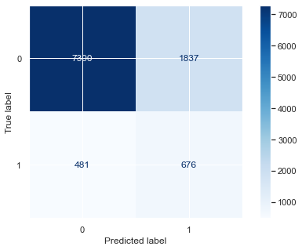

```python
# Running logistic regression
lr = custom_pipeline(LogisticRegression(),display=True)
```

### Decision Tree Model

```
Training_Accuracy: 0.9960036496350365
Test_Accuracy: 0.8277637458713814
Precision: 0.8486718628825708
Recall: 0.8277637458713814
F1_Score: 0.8372802689160288
```

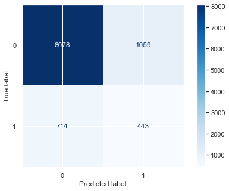

```python
# Running Decision Tree
dt = custom_pipeline(DecisionTreeClassifier(), display= True)
```

### XG Boost Model

```
[22:45:59] WARNING: /opt/concourse/worker/volumes/live/7a2b9f41-3287-451b-6691-43e9a6c0910f/volume/xgboost-split_1619728204606/work/src/learner.cc:1061: Starting in XGBoost 1.3.0, the default evaluation metric used with the objective 'binary:logistic' was changed from 'error' to 'logloss'. Explicitl…
[22:46:03] WARNING: /opt/concourse/worker/volumes/live/7a2b9f41-3287-451b-6691-43e9a6c0910f/volume/xgboost-split_1619728204606/work/src/learner.cc:1061: Starting in XGBoost 1.3.0, the default evaluation metric used with the objective 'binary:logistic' was changed from 'error' to 'logloss'. Explicitl…
Training_Accuracy: 0.9265875912408759
Test_Accuracy: 0.8805129201476588
Precision: 0.8794316540563437
Recall: 0.8805129201476588
F1_Score: 0.8799651477256526
```

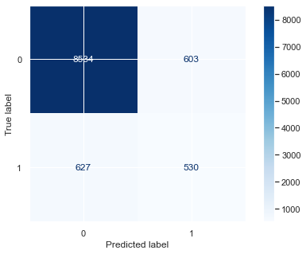

```python
# Running XG Boost
xgboost = custom_pipeline(XGBClassifier(n_jobs=-1),display= True)
```

### Random Forest Model

```
Training_Accuracy: 0.9960036496350365
Test_Accuracy: 0.8725471148241695
Precision: 0.8714882394917857
Recall: 0.8725471148241695
F1_Score: 0.8720120577207873
```

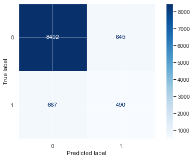

```python
# Running Random Forest
rf = custom_pipeline(RandomForestClassifier(),display= True)
```

```python
rf
```

```
(0.9960036496350365,
 0.8725471148241695,
 0.8714882394917857,
 0.8725471148241695,
 0.8720120577207873,
 array([0, 0, 0, ..., 0, 0, 0]),
 array([0.44, 0.02, 0.42, ..., 0.04, 0.  , 0.02]),
 Pipeline(steps=[('preprocessor',
                  ColumnTransformer(transformers=[('num', StandardScaler(),
                                                   ['pdays', 'count', 'campaign',
                                                    'previous', 'euribor3m',
                                                    'cons_conf_idx', 'age',
                                                    'cons_price_idx']),
                                                  ('cat', OneHotEncoder(),
                                                   ['job', 'marital',
                                                    'education', 'default',
                                                    'housing', 'loan', 'contact',
                                                    'month', 'day_of_week',
                                                    'poutcome',
                                                    'age_group'])])),
                 ('model', RandomForestClassifier())]))
```

```python
# pipe_models[-2]
```

# function-pipeline

### Evaluating Models

```python
# Creating a data frame to collect all the results and evaluate them

models_DataFrame = pd.DataFrame(columns=['Model','Train_Accuracy','Test_Accuracy',
                                         'Precision','Recall','F1_score'])
list_models = [LogisticRegression(),DecisionTreeClassifier(),
              RandomForestClassifier(n_jobs=-1),XGBClassifier(n_jobs=-1)]

model_names = 'Lositic_Regression  Decision_Tree Random_Forest XGboost'.split()

from tqdm import tqdm
x_probs  = []
pipe_models = []

for model,model_name in tqdm(zip(list_models,model_names)):
    train_acc,test_acc,precision,recall,f1,_,x_prob,pipe_model = custom_pipeline(model)
    x_probs.append(x_prob)
    pipe_models.append(pipe_model)
    models_DataFrame.loc[len(models_DataFrame)] = [model_name,train_acc,test_acc,precision,recall,f1]
```

```
1it [00:01,  1.67s/it]
```

```
2it [00:02,  1.30s/it]
```

```
3it [00:05,  1.91s/it]
```

[output not shown]

```
4it [00:12,  3.17s/it]
```

```python
# Diplay data frame
models_DataFrame
```

|  | Model | Train_Accuracy | Test_Accuracy | Precision | Recall | F1_score |
| --- | --- | --- | --- | --- | --- | --- |
| 0 | Lositic_Regression | 0.768741 | 0.774820 | 0.862970 | 0.774820 | 0.807396 |
| 1 | Decision_Tree | 0.996004 | 0.826792 | 0.847562 | 0.826792 | 0.836269 |
| 2 | Random_Forest | 0.995985 | 0.871381 | 0.870507 | 0.871381 | 0.870941 |
| 3 | XGboost | 0.926588 | 0.880513 | 0.879432 | 0.880513 | 0.879965 |

```python
# Checking which one was the top performer
# models_DataFrame.sort_values('Test_Accuracy',ascending=False).values[0][0]
```

```python
# Preparing for plotting x and y axis
x_plot = models_DataFrame["Model"]
y_plot = models_DataFrame["F1_score"]
```

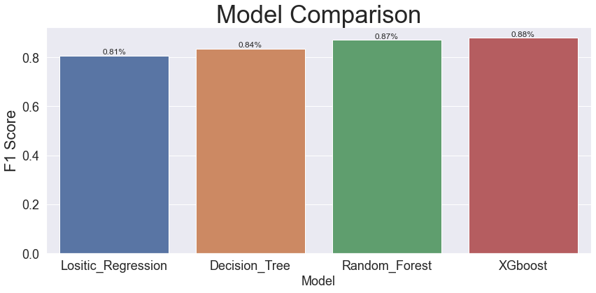

```python
# Plotting model results

fig, ax = plt.subplots(figsize=(12,6))

sns.barplot(x=x_plot, y=y_plot)

# Lable and define fontsize for main and axis titles.

plt.xlabel('Model', fontsize=18)
plt.ylabel('F1 Score', fontsize=22)
plt.title('Model Comparison', fontsize=35)
plt.tick_params(axis='both', which='major', labelsize=18)

for bars in ax.containers:
        ax.bar_label(bars, fmt="%.2f%%")
#Set x-axis tick labels.


plt.tight_layout()
plt.show()
```

# Hyperparameter Tuning using GridSearch

### Xgboost - Hyperparameter Tuning

```python
pipe_models[-1]
```

```
Pipeline(steps=[('preprocessor',
                 ColumnTransformer(transformers=[('num', StandardScaler(),
                                                  ['pdays', 'count', 'campaign',
                                                   'previous', 'euribor3m',
                                                   'cons_conf_idx', 'age',
                                                   'cons_price_idx']),
                                                 ('cat', OneHotEncoder(),
                                                  ['job', 'marital',
                                                   'education', 'default',
                                                   'housing', 'loan', 'contact',
                                                   'month', 'day_of_week',
                                                   'poutcome',
                                                   'age_group'])])),
                ('model',
                 XGBClassifier(base_sco...
                               colsample_bytree=1, gamma=0, gpu_id=-1,
                               importance_type='gain',
                               interaction_constraints='',
                               learning_rate=0.300000012, max_delta_step=0,
                               max_depth=6, min_child_weight=1, missing=nan,
                               monotone_constraints='()', n_estimators=100,
                               n_jobs=-1, num_parallel_tree=1, random_state=0,
                               reg_alpha=0, reg_lambda=1, scale_pos_weight=1,
                               subsample=1, tree_method='exact',
                               validate_parameters=1, verbosity=None))])
```

```python
pipe_models[-2]
```

```
Pipeline(steps=[('preprocessor',
                 ColumnTransformer(transformers=[('num', StandardScaler(),
                                                  ['pdays', 'count', 'campaign',
                                                   'previous', 'euribor3m',
                                                   'cons_conf_idx', 'age',
                                                   'cons_price_idx']),
                                                 ('cat', OneHotEncoder(),
                                                  ['job', 'marital',
                                                   'education', 'default',
                                                   'housing', 'loan', 'contact',
                                                   'month', 'day_of_week',
                                                   'poutcome',
                                                   'age_group'])])),
                ('model', RandomForestClassifier(n_jobs=-1))])
```

```python
# Checking the location of the model and its keys

pipeline_xgboost = pipe_models[-1]
pipeline_xgboost.get_params().keys()
```

```
dict_keys(['memory', 'steps', 'verbose', 'preprocessor', 'model', 'preprocessor__n_jobs', 'preprocessor__remainder', 'preprocessor__sparse_threshold', 'preprocessor__transformer_weights', 'preprocessor__transformers', 'preprocessor__verbose', 'preprocessor__num', 'preprocessor__cat', 'preprocessor__…
```

```python
# The below cells are commented since  it takes a couple of hours to runthough all the parameters.

# params_xgBoost = {
#         'model__min_child_weight': [1, 5, 10,15,20],
#         'model__gamma': [0.5, 1, 1.5, 2, 5,6,7,8],
# #         'model__subsample': [0.6, 0.8, 1.0],
# #         'model__colsample_bytree': [0.6, 0.8, 1.0],
#         'model__max_depth': [3, 4, 5,6,7,8]
#         }
```

```python
# Using GridSearch to find the best parameters

# GrifSearch

#grid_clf_xgboost = GridSearchCV(pipeline_xgboost, params_xgBoost, scoring='f1',
                        # cv=3, n_jobs=-1,verbose=3)
```

```python
# Fitting the model

# xgboost_tuned = grid_clf_xgboost.fit(X_train, y_train)
```

```python
# Obtaining best parameters

#best_param = xgboost_tuned.best_params_
#best_param
```

```python
# {'model__gamma': 0.5, 'model__max_depth': 3, 'model__min_child_weight': 1}
```

```python
best_param = {'model__gamma': 0.5, 'model__max_depth': 3, 'model__min_child_weight': 1}
```

[output not shown]

[figure not shown]

```python
# Checking the tuned result for XG boost

model_tuned_pipeline_xgboost = custom_pipeline(XGBClassifier(**best_param),display=True)
```

```python
# Named_steps['model']  allows us to see the details of al the parameters,

model_tuned_pipeline_xgboost[-1].named_steps['model']
```

[output not shown]

```python
# Looking at the steps
model_tuned_pipeline_xgboost
```

[output not shown]

```python
# Obtaining the propbilies for XG Boost

y_probs_xgboost_t = model_tuned_pipeline_xgboost[-2]
y_probs_xgboost_t
```

```
array([0.5910047 , 0.11283673, 0.47228602, ..., 0.04543665, 0.02450125,
       0.02996808], dtype=float32)
```

### Random Forest - Hyperparameter Tuning

```python
# Verifying that this is where Random Forest is stored.
pipe_models[-2]
```

```
Pipeline(steps=[('preprocessor',
                 ColumnTransformer(transformers=[('num', StandardScaler(),
                                                  ['pdays', 'count', 'campaign',
                                                   'previous', 'euribor3m',
                                                   'cons_conf_idx', 'age',
                                                   'cons_price_idx']),
                                                 ('cat', OneHotEncoder(),
                                                  ['job', 'marital',
                                                   'education', 'default',
                                                   'housing', 'loan', 'contact',
                                                   'month', 'day_of_week',
                                                   'poutcome',
                                                   'age_group'])])),
                ('model', RandomForestClassifier(n_jobs=-1))])
```

```python
# Checking the location of the model and its keys


pipeline_rf = pipe_models[-2]
pipeline_rf.get_params().keys() # Checking the keys for the parameters
```

```
dict_keys(['memory', 'steps', 'verbose', 'preprocessor', 'model', 'preprocessor__n_jobs', 'preprocessor__remainder', 'preprocessor__sparse_threshold', 'preprocessor__transformer_weights', 'preprocessor__transformers', 'preprocessor__verbose', 'preprocessor__num', 'preprocessor__cat', 'preprocessor__…
```

```python
df_bank.isna().sum()
```

```
age               0
job               0
marital           0
education         0
default           0
housing           0
loan              0
contact           0
month             0
day_of_week       0
campaign          0
pdays             0
previous          0
poutcome          0
cons_price_idx    0
cons_conf_idx     0
euribor3m         0
subscribed        0
age_group         0
count             0
dtype: int64
```

```python
# The below cells are commented since  it takes a couple of hours to runthough all the parameters.

# param_grid_rf = {
#     'model__n_estimators': [100, 300, 900, 1200],
#      'model__max_features': [2, 4,8,16,18,60],
#      'model__max_depth' : [50, 100 ,300, 600],
#      'model__criterion' :['gini', 'entropy']
# }
```

```python
# GrifSearch
# grid_clf_rf = GridSearchCV(pipeline_rf, param_grid_rf, scoring='accuracy',
#                          cv=3, n_jobs=-1,verbose=2)
```

```python
# grid_clf_rf.fit(X_train, y_train)
```

```python
# best_params_rf = grid_clf_rf.best_params_
```

```python
# # Using the best parameters
best_params_rf = {'model__criterion': 'gini',
'model__max_depth': 300,
'model__max_features': 60,
'model__n_estimators': 960}
```

```python
# Removing ‘_’ - to match the code out side of the pipeline
best_params_rf = {k.split('__')[1]:best_params_rf[k] for k in best_params_rf}
```

```python
# RandomForestClassifier(criterion='gini',max_depth=200, )

# {'model__criterion': 'gini',
#  'model__max_depth': 200,
#  'model__max_features': 14,
#  'model__n_estimators': 900}
```

```python
# Applying best parameters
clf_rf = RandomForestClassifier(**best_params_rf)
```

```python
# Checking if worked
clf_rf
```

```
RandomForestClassifier(max_depth=300, max_features=60, n_estimators=960)
```

```
Training_Accuracy: 0.9960036496350365
Test_Accuracy: 0.8729356906936079
Precision: 0.8685113598591178
Recall: 0.8729356906936079
F1_Score: 0.8706234452833183
```

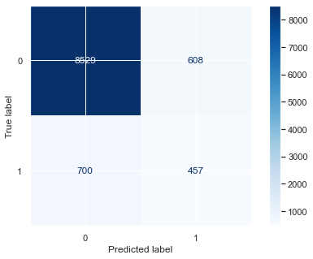

```python
# Model tuned results
model_tuned_pipeline_rf = custom_pipeline(clf_rf,display=True)
```